# Measures of Variability

### Violin Plots

With the rise of compuatational power, it is now possible to create visualizations that are more informative than the traditional box-and-whisker plot.

Consider the three violin plots below, which uses the same data as the box-and-whiser plots above.

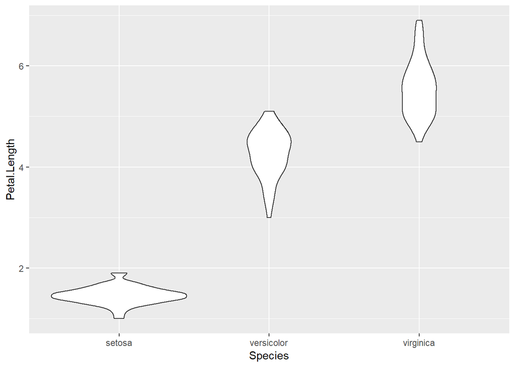

To help understand the information that is conveyed in a violin plot, let’s zoom back in on the virginica species.

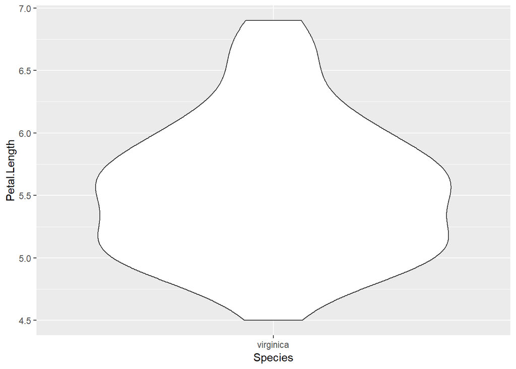

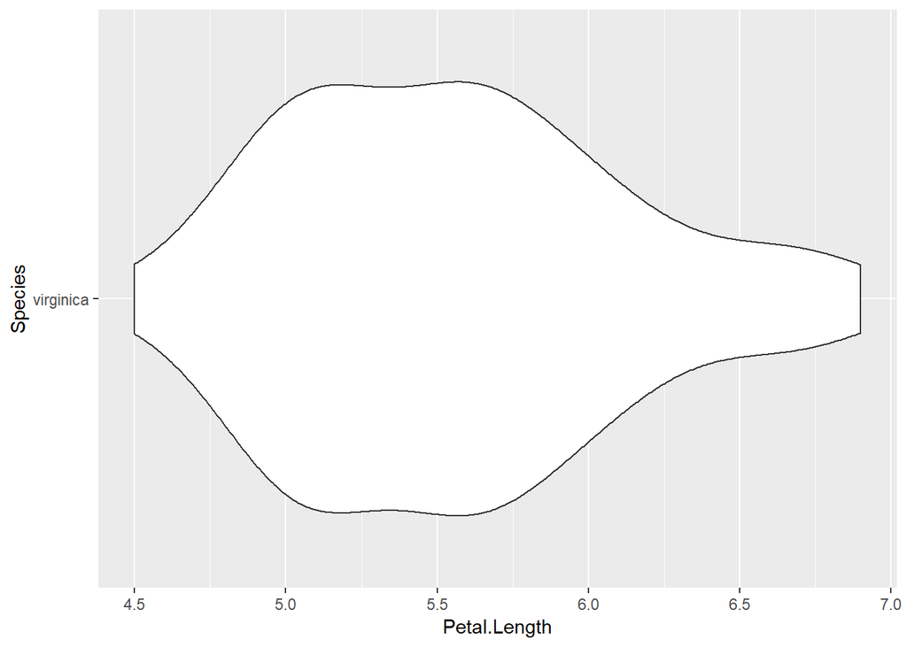

Now compare the shape of the violin with the histogram below.

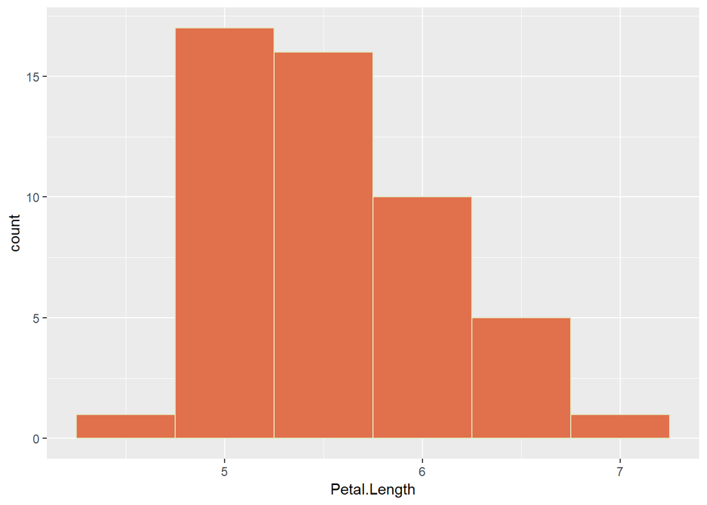

In summary, a violin plot gives information about the range of our data and the density of our data at the same time.

# Sample Variance and Sample Standard Deviation

In the previous section, we talked about the range and the interquartile range. These are examples of order statistics because they rely on ordering our data from least to greatest.

Now let’s look at some measures of variability that are not order statistics.

In one of the sections above, we visualized the variation of the “mpg” variable in the cars dataset by creating a bar plot where the length of each bar corresponded to an observed value of the “mpg” variable. Here is that plot again, for reference:

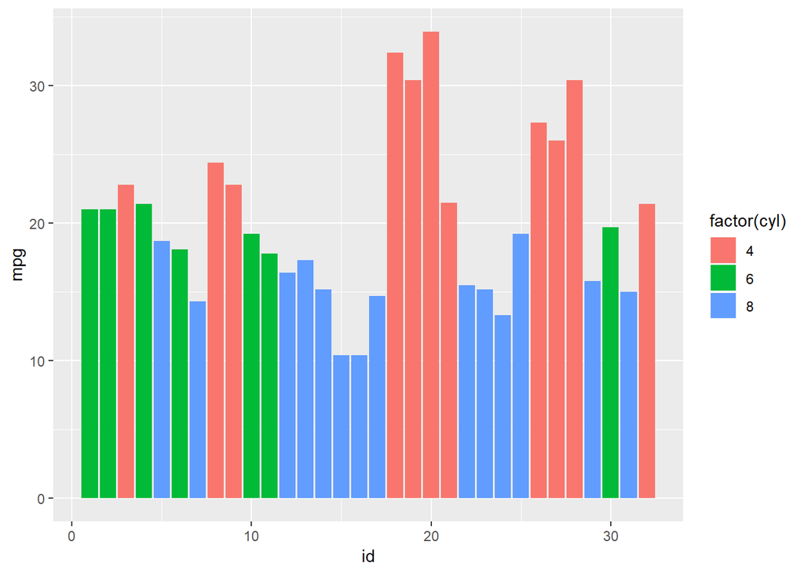

This gave us a simple way to visualize the range of the mpg variable.

Now, let’s consider another way to think about the variation of the mpg variable.

In the plot below, we have indicated the value of the “mpg” variable for each observation in our data set by drawing a blue dot with an $x$ coordinate that corresponds to the value of “mpg”.

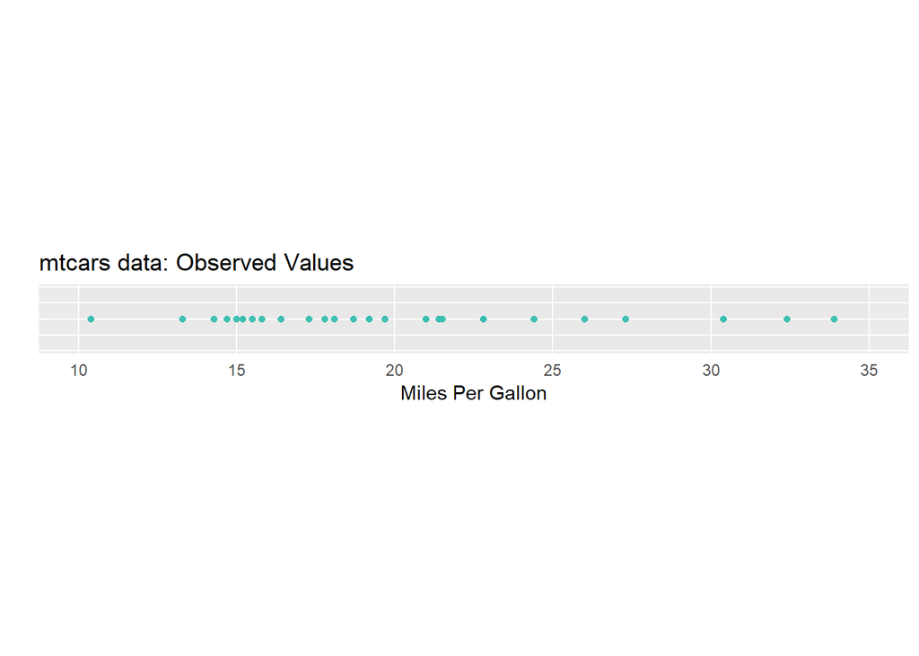

Note that one issue with this sort of visualization is as follows: if multiple observations in our data have the same “mpg” value, then this fact will be obscured by the visualization above.

Indeed, the cars with ids 15 and 16 had mpg values of 10.4.

Nevertheless, let’s proceed with the visualzation above.

Next, we include a large pink dot that symbolizes the mean $\overline{x}$ of the mpg values.

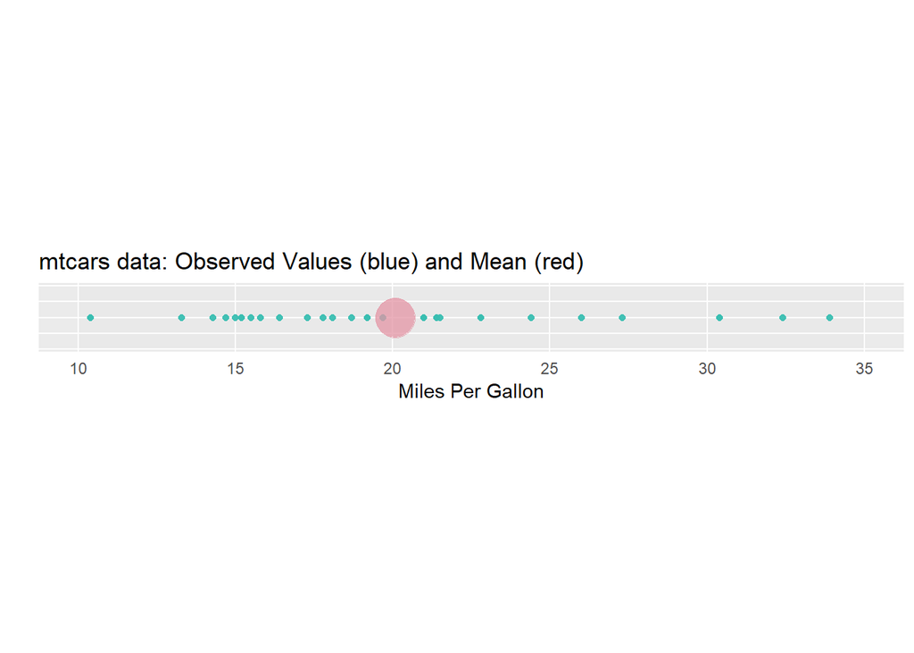

One way to measure the variability of our dataset is as follows. For each observation $x_j$ in our dataset, find the distance between $x_j$ and the mean $\overline{x}$ and then square the result:
$$|x_j - \overline{x}|^2$$
Next, add up all of these “squared distances” and divide by $n-1$, where $n$ is the total number of observations in our dataset:
$$\sum_{j=1}^n \frac{|x_j - \overline{x}|^2}{n-1}$$

The expression above is called the *sample variance* for our variable.

Sample variance is denoted by the symbol $s^2$.

Since $|a-b|^2 = (a-b)^2$ for real numbers $a$ and $b$, the expression above is normally written as follows:

$$s^2 = \text{Sample Variance} = \sum_{j=1}^n \frac{(x_j - \overline{x})^2}{n-1}$$

## Visualizing Variance

Now we consider a way that we can actually visualize variance.

Consider the set of numbers $X = \{8,10,14, 18\}$.

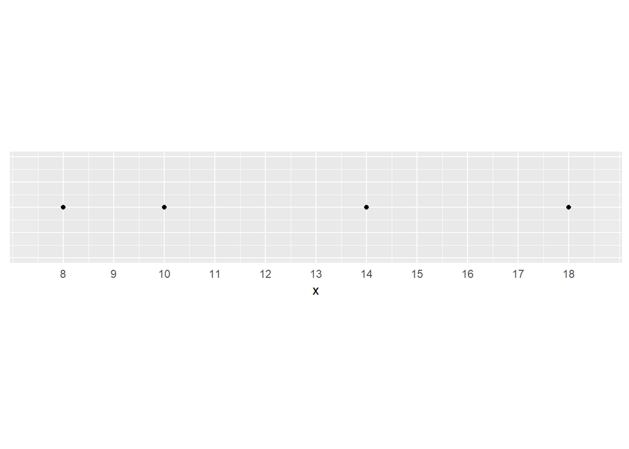

For this set of data, we have $\overline{x} = 12.5$.

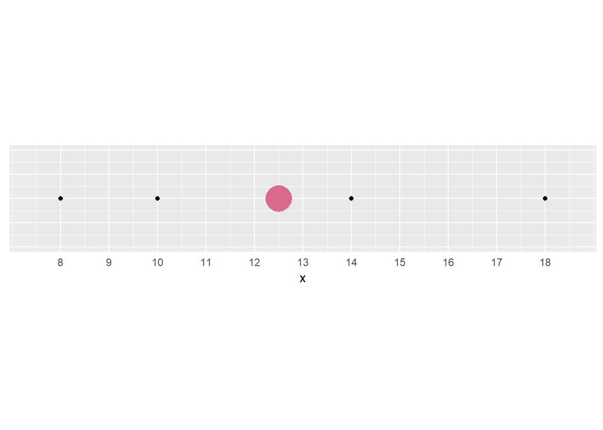

The formula for the sample variance of $X$ is given by
$$s^2 = \sum_{j=1}^4 \frac{(x_j - \overline{x})^2}{3} = \frac{1}{3} \left[ (x_1 -\overline{x})^2 +
(x_2 -\overline{x})^2 + (x_3 -\overline{x})^2 + (x_4 -\overline{x})^2 \right]$$

Note that we can view the sample variance of $X$ as one third of the sum of the areas of the squares below:

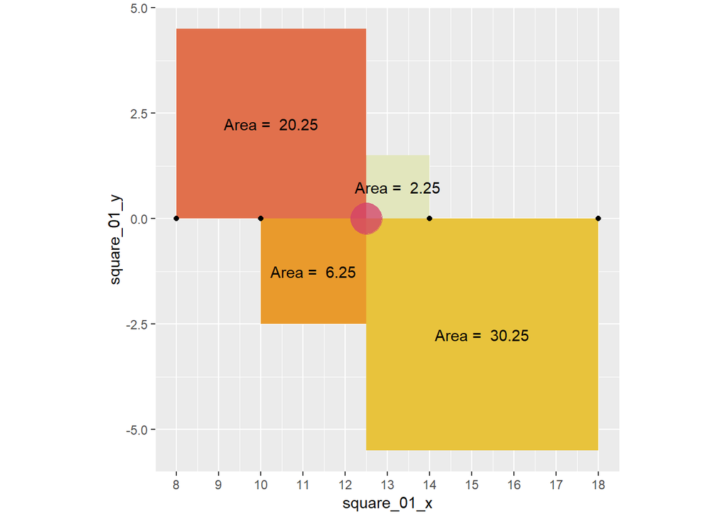

Indeed, the area of the orange square on the top left is given by
$$(x_1 - \overline{x})^2 = (8-12.5)^2 = |4.5| ^2 = 20.25$$

Note that $4.5$ is the length of a side of the square.

Thinking about variance in this manner emphasizes the fact that values that are “far away” from the mean will affect the variance moreso than values that are close to the mean.

## Sample Standard Deviation

The standard deviation of a sample is defined to be the square root of the sample variance.

$$\text{Sample Standard Deviation} = s = \sqrt{s^2}$$

For example, we can ask R to compute the variance and standard deviation for “mpg” variable inthe “mtcars” dataset as follows:

```r
sd(mtcars$mpg)
```

```
## [1] 6.026948
```

```r
var(mtcars$mpg)
```

```
## [1] 36.3241
```

The first computation tells us that the standard deviation for our data is about 6 miles per gallon, while the second computation tells us that the variance is about 36 miles squared per gallons squared.

We will discuss interpretations of standard deviation in a little bit, after we introduce the concepts of population variance and standard deviation.

# Population Variance and Standard Deviation

So far we have been talking about the sample variance $s^2$ and the sample standard deviation $s$.

These are measurements we use when have a set of data (i.e., a sample) that has been taken from some large population.

If we had all of the data for a population with size $N$, then we could find the mean $\mu$, the variance $\sigma^2$, and the standard deviation $\sigma$ for that population using the following formulas.

$$\text{Population Mean} = \mu = \frac{\sum_{j=1}^N x_j}{N}$$

$$\text{Population Variance} = \sigma^2 = \frac{\sum _{j=1}^N (x_j - \mu)^2}{N}$$

$$\text{Population Standard Deviation} = \sigma = \sqrt{\sigma^2}$$

## Interpreting Standard Deviation for Populations

When speaking about a particular value $x_0$ in a population with a mean $\mu$, we will sometimes use a phrase such as “$x_0$ is one standard deviation from the mean”.

Another way to say this is “the distance from the element $x_0$ to the mean $\mu$ is one times the standard deviation $\sigma$”.

Let’s translate this English phrase into a mathematical statement:

$$\begin{align*}
|x_0 - \mu | & = 1 \times \sigma
\end{align*}$$

If we square both sides of the equation above, then we will have an expression whose informational content is mathematically equivalent to the one above:

$$\begin{align*}
|x_0 -\mu|^2 & = \sigma^2
\end{align*}$$

Meanwhile, by definition, we have

$$\begin{align*}
\sigma^2 = \sum_{j =1}^N \frac{|x_j - \mu|^2}{N}
= \text{the average squared distance from $\mu$}
\end{align*}$$

Note that we can interpret the expression on the right as “the average squared distance from $\mu$ (with respect to all of the elements $x_j$ in our population)”.

In summary, we have shown that the statement “$x_0$ is one standard deviation from the population mean $\mu$” is equivalent to the statement ``the squared distance from $x_0$ to the mean is equal to the average squared distance from $\mu$ for our population."

To be more precise, the phrase “average squared distance from $\mu$ for our population” means

- find the distance from $x_j$ to $\mu$ for each element of our population,
- square those distances, and then
- find the average of all of those squared distances.

## Interpreting Standard Deviation for Samples

We can do a similar calculation for sample standard deviation.

$$\begin{align*}
|x_0 - \overline{x}| & = 1 \times s
\end{align*}$$

If we square both sides of the equation above, then we obtain

$$\begin{align*}
|x_0 - \overline{x}|^2 & = s^2
\\
& = \sum_{j =1}^n \frac{|x_j - \overline{x}|^2}{n-1}
\\
& = \frac{n}{n-1} \times \sum_{j =1}^n \frac{|x_j - \overline{x}|^2}{n}
\\
& \approx \sum_{j =1}^n \frac{|x_j - \overline{x}|^2}{n}
\end{align*}$$

This shows that the statement “$x_0$ is one standard deviation from the sample mean $\overline{x}$” is equivalent to the statement ``the squared distance from $x_0$ to the mean $\overline{x}$ is *almost* equal to the average squared distance from $\overline{x}$ for our sample“.

Once again, to be more precise, the phrase “average squared distance from $\overline{x}$ for our sample” means

- find the distance from $x_j$ to $\overline{x}$ for each element of our sample,
- square those distances, and then
- find the average of all of those squared distances.

Above, we said that the statement “$x_0$ is one standard deviation from the sample mean $\overline{x}$” is equivalent to the statement ``the squared distance from $x_0$ to the mean $\overline{x}$ is *almost* equal to the average squared distance from $\overline{x}$ for our sample“.

What do we mean by “almost”? Consider the table below.

| n | n/(n-1) |
| --- | --- |
| 10 | 1.111111 |
| 20 | 1.052632 |
| 30 | 1.034483 |
| 40 | 1.025641 |
| 50 | 1.020408 |
| 60 | 1.016949 |
| 70 | 1.014493 |
| 80 | 1.012658 |
| 90 | 1.011236 |
| 100 | 1.010101 |

The relevance of this table is as follows. As our sample size $n$ increases, the ratio $\displaystyle{\frac{n}{n-1}}$ approaches $1$.

This is why we wrote

$$\frac{n}{n-1} \times \sum_{j =1}^n \frac{|x_j - \overline{x}|^2}{n}
\approx \sum_{j =1}^n \frac{|x_j - \overline{x}|^2}{n}$$
above.

# Median Absolute Deviation

Let $X = \{x_j\}_{j=1}^n$ be a set of real numbers and let $\tilde{x}$ denote the median of the set. The *median absolute deviation* for $X$ is defined to be the median of the set $\{ |x_j - \tilde{x}|\}_{j=1}^n$.

As we saw above, the variance and standard deviation of $X = \{x_j\}_{j=1}^n$ will be heavily influenced by “extreme values” or outliers in our data.

The Median Absolute Deviation is not as easily swayed by these extreme values.